# Análise de Dados e Administração de Empresas

UFRGS Portas Abertas

Marcelo S. Perlin

EA-UFRGS

03/06/2023

## Programação

- Sobre o autor
- Sobre o R
- Carreira de analista de dados

# Sobre o professor

## Marcelo S. Perlin (ou prof Perlin)

> Professor Associado na EA/UFRGS, orientador de mestrado e doutorado. Com mais de 16 anos de carreira em análise de dados voltada a ciência, finanças quantitativas e consultoria para empresas.
- Apaixonado por análise de dados, programação e investimentos.
- Programador e consultor em **R** e **Python**.
- Autor de diversos pacotes de código aberto no R: `yfR`, `GetTDData`, `GetBCBData`, etc.
- Autor de livros sobre análise de dados e investimentos (detalhes a seguir)
- Contato
  - Email: marceloperlin@gmail.com
  - Site: https://www.msperlin.com/

## Quem sou eu?

- Professor de graduação e pós-graduação da Escola de Administração da UFRGS. marceloperlin@gmail.com | https://www.msperlin.com/blog/
- Desenvolvedor e mantenedor de pacotes *open source* do R
- Apaixonado por análise de dados e produção de ciência

## Livros

[figure not shown]

[figure not shown]

[figure not shown]

[figure not shown]

## O que é o R

> O R é uma linguagem de programação voltada para a resolução de problemas estatísticos e para a visualização gráfica de dados.
- Autores: Ross Ihaka e Robert Gentleman (*The University of Auckland*), criada em 1993
- Funcionalidade: R é sinônimo de programação voltada à análise de dados
- Custo: **O R é totalmente livre** e disponível em vários sistemas operacionais.

## Por que Escolher o R

- Plataforma gratuita, madura, estável, e continuamente suportada.
- quantidade absurda de módulos adicionais
- fácil de aprender
- **Permite trilhar uma carreira profissional em análise de dados!**

## Carreira de Analista de Dados

- a ciência de dados é uma tendência positiva no mercado de trabalho
- salários altos, com uma demanda maior do que a oferta
- boa qualidade de vida, com possibiliade de trabalhar para o exterior

## Sálarios Analista de dados junior

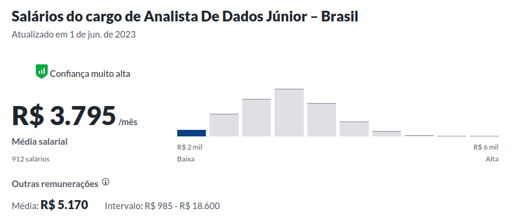

## Sálarios Analista de dados senior

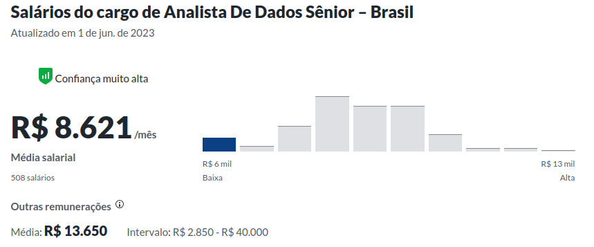

# Exemplos de Aplicação

## O lucro histórico da Petrobrás (PETR3)

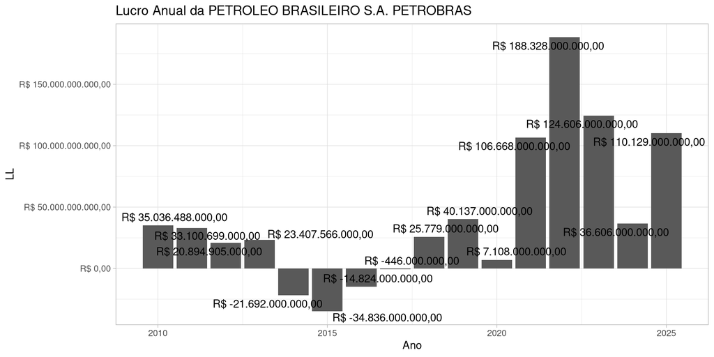

## Retorno Real da Poupança

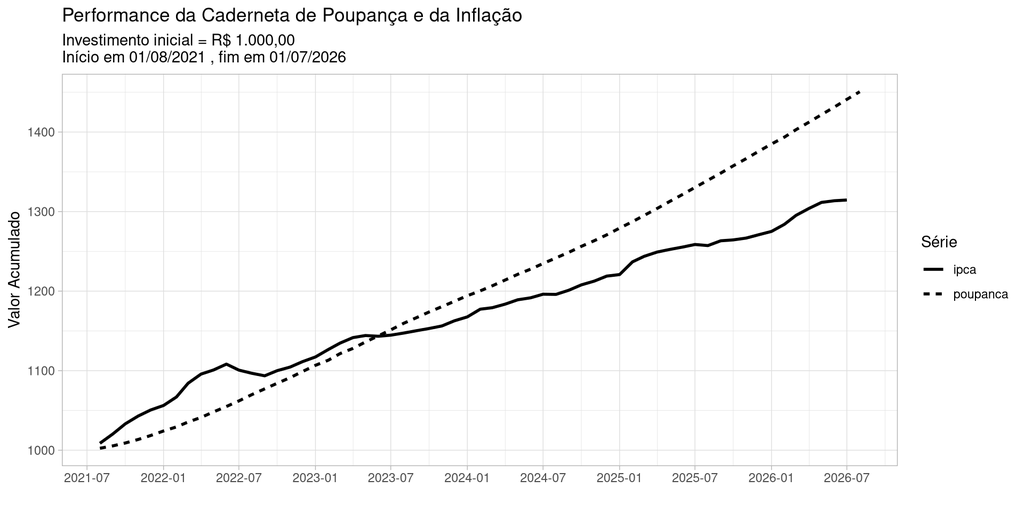

Poupança e Inflação

## Performance do Ibovespa

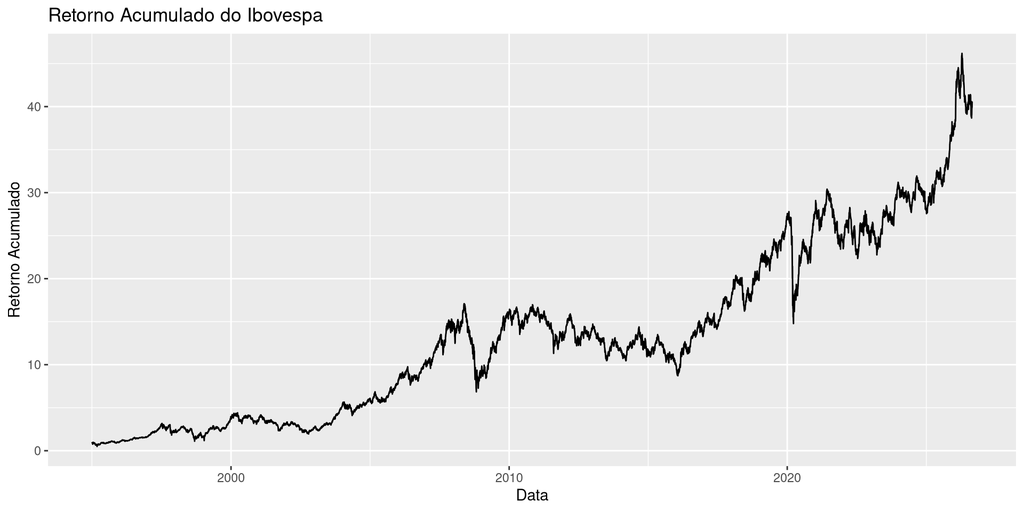

## A dinâmica da Estrutura a Termo no Brasil